# Prediction HRA

Agustin Pacheco Bonrostro

9 de mayo de 2018

## Introduction

Using devices such as Jawbone Up, Nike FuelBand, and Fitbit it is now possible to collect a large amount of data about personal activity relatively inexpensively. These type of devices are part of the quantified self movement - a group of enthusiasts who take measurements about themselves regularly to improve their health, to find patterns in their behavior, or because they are tech geeks. One thing that people regularly do is quantify how much of a particular activity they do, but they rarely quantify how well they do it. In this project, your goal will be to use data from accelerometers on the belt, forearm, arm, and dumbell of 6 participants. They were asked to perform barbell lifts correctly and incorrectly in 5 different ways. More information is available from the website here: [HAR Project](http://web.archive.org/web/20161224072740/http:/groupware.les.inf.puc-rio.br/har)

## Project Objetive

The goal of your project is to predict the manner in which they did the exercise. This is the “classe” variable in the training set. You may use any of the other variables to predict with. You should create a report describing how you built your model, how you used cross validation, what you think the expected out of sample error is, and why you made the choices you did. You will also use your prediction model to predict 20 different test case

We will have two datasets. [Training Dataset](https://d396qusza40orc.cloudfront.net/predmachlearn/pml-training.csv) [Testing Dataset](https://d396qusza40orc.cloudfront.net/predmachlearn/pml-testing.csv)

## Necessary Libraries

The following libraries will be necessary to perform the analysis

```r
library (caret)
library(rattle)
library(randomForest)
library(rpart)
library (BBmisc)
library(pROC)
library(ggplot2)
library(grid)
library(gridExtra)
```

Let’s initialize somme values

```r
nwd <- "F:\\Coursera\\R\\wd"
fileURLTrain <- "https://d396qusza40orc.cloudfront.net/predmachlearn/pml-training.csv"
fileNameTrain <- "pml-trainning.csv"
fileURLTest <- "https://d396qusza40orc.cloudfront.net/predmachlearn/pml-testing.csv"
fileNameTest <- "pml-testing.csv"


seedval <- 34243
```

## Auxiliary Function

Somme auxiliary funtions will help us

### getIndex

```r
getIndex <- function(df, pct) {
        ### Obtain the index of the columns with % of Non NA greather than PCT
        ncol <- dim(df)[2]
        nrow  <- dim(df)[1]

        ind<-1

        indices <- array()
        ## For all columns
        for(i in 1: ncol) {
                col <- df[, i]
                numNA <- sum(is.na(col))
                ## if % of NA is greather than pct include i in indices array
                if ( (numNA/nrow) * 100 < pct) {
                        indices[ind] <- i
                        ind <- ind + 1
                }
        }

        ## Return indices array
        indices
}
```

### readDataset

```r
##
readDataSet <- function( nameDir, fileName, fileURL ) {

        ## Obtain original work directory
        owd <- getwd()
        ## If not exists the directory, create
        if(!file.exists(nameDir)){
                dir.create(nameDir)
        }
        setwd(nameDir)


        ## If the file dont exists...
        if(!file.exists(fileName)){
                ## Download the file
                download.file(fileURL,destfile=fileName,method="curl")
        }

        ## Read CSV file
        dataF <- read.csv(fileName, header = TRUE, na.strings = c("NA", "#DIV/0!", ""))

        ## Return to initial work directory
        setwd(owd)
        dataF
}
```

### plotConfusion

```r
plotConfusion <- function(conf) {


        df <- normalize(as.data.frame(conf$table))
        plot <- ggplot(df)
        plot + geom_tile(aes(x=Prediction, y=Reference, fill=Freq)) +
                scale_x_discrete(name="Actual Class") +
                scale_y_discrete(name="Predicted Class") +
            ##    scale_fill_gradient(breaks=seq(from=-.3, to=3, by=.2)) +
                labs(fill="Normalized\nFrequency")


      print(plot)

}
```

## Analysis

### Initialize Seed and Download Data Sets

```r
## Read train and test Data Sets
set.seed(seedval)
trainnig <- readDataSet(nwd, fileNameTrain, fileURLTrain )
testing <- readDataSet(nwd, fileNameTest, fileURLTest )

## The first 7 columns are not useful for analysis
trainnig <- trainnig[, -c(1:7)]
testing <- testing[, -c(1:7)]
## Obtain the index of the columns with useful data
indices <- getIndex(trainnig, 60)

## We will use this columns
trainnig <- trainnig[, indices]
testing <- testing[, indices]
```

The testing dataset has not the classe column. We will use this data set to predict the classe value, as final step

## Create the analisys Data Sets

```r
inTrain <- createDataPartition(trainnig$classe, p=.7, list=FALSE)
trainD.train <- trainnig[inTrain,]
trainD.test  <- trainnig[-inTrain,]
```

## Decision Tree

Our first model will be a decission Tree

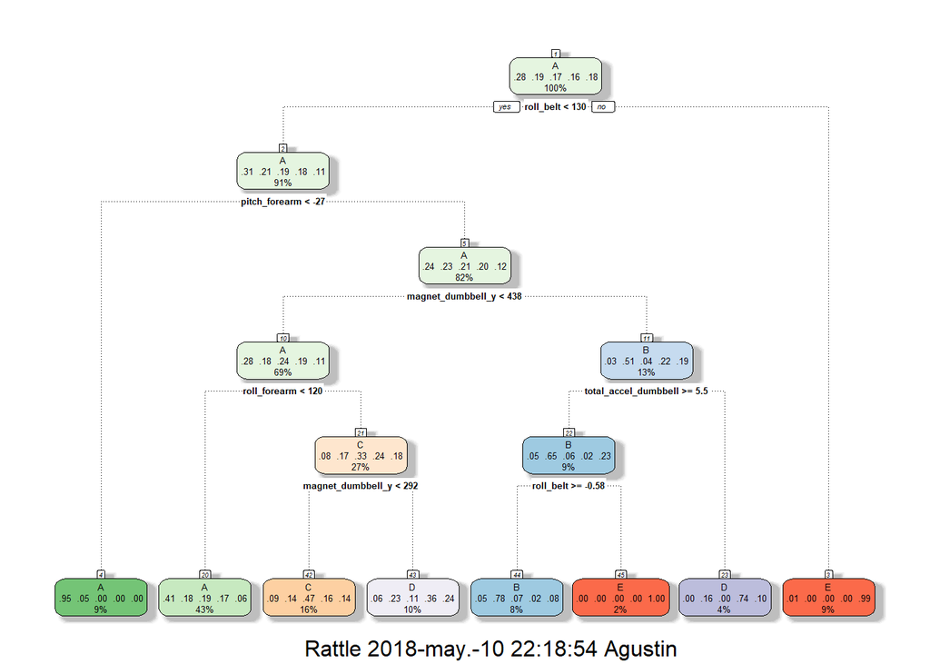

```r
dt.model <- train(classe ~ ., data=trainD.train, method="rpart2")

fancyRpartPlot(dt.model$finalModel)
```

```r
dt.classe <- predict(dt.model, newdata = trainD.test)

dt.conf <- confusionMatrix( trainD.test$classe, dt.classe)
dt.conf
```

```
## Confusion Matrix and Statistics
##
##           Reference
## Prediction    A    B    C    D    E
##          A 1520   26   80   42    6
##          B  482  329  135  193    0
##          C  469   36  438   83    0
##          D  428   15  131  390    0
##          E  175   42  133  200  532
##
## Overall Statistics
##
##                Accuracy : 0.5453
##                  95% CI : (0.5325, 0.5581)
##     No Information Rate : 0.5223
##     P-Value [Acc > NIR] : 0.0002217
##
##                   Kappa : 0.4075
##  Mcnemar's Test P-Value : < 2.2e-16
##
## Statistics by Class:
##
##                      Class: A Class: B Class: C Class: D Class: E
## Sensitivity            0.4945  0.73438  0.47764  0.42952  0.98885
## Specificity            0.9452  0.85102  0.88164  0.88467  0.89714
## Pos Pred Value         0.9080  0.28885  0.42690  0.40456  0.49168
## Neg Pred Value         0.6310  0.97493  0.90142  0.89474  0.99875
## Prevalence             0.5223  0.07613  0.15582  0.15429  0.09142
## Detection Rate         0.2583  0.05590  0.07443  0.06627  0.09040
## Detection Prevalence   0.2845  0.19354  0.17434  0.16381  0.18386
## Balanced Accuracy      0.7198  0.79270  0.67964  0.65709  0.94299
```

## Random Forest

```r
rf.model <- randomForest(classe ~ ., data=trainD.train, ntree=50, norm.votes=FALSE)
rf.classe <- predict(rf.model, newdata = trainD.test, method ="class")

rf.conf <- confusionMatrix( trainD.test$classe, rf.classe)
rf.conf
```

```
## Confusion Matrix and Statistics
##
##           Reference
## Prediction    A    B    C    D    E
##          A 1674    0    0    0    0
##          B   10 1127    2    0    0
##          C    0    8 1016    2    0
##          D    0    0    9  953    2
##          E    0    0    2    2 1078
##
## Overall Statistics
##
##                Accuracy : 0.9937
##                  95% CI : (0.9913, 0.9956)
##     No Information Rate : 0.2862
##     P-Value [Acc > NIR] : < 2.2e-16
##
##                   Kappa : 0.992
##  Mcnemar's Test P-Value : NA
##
## Statistics by Class:
##
##                      Class: A Class: B Class: C Class: D Class: E
## Sensitivity            0.9941   0.9930   0.9874   0.9958   0.9981
## Specificity            1.0000   0.9975   0.9979   0.9978   0.9992
## Pos Pred Value         1.0000   0.9895   0.9903   0.9886   0.9963
## Neg Pred Value         0.9976   0.9983   0.9973   0.9992   0.9996
## Prevalence             0.2862   0.1929   0.1749   0.1626   0.1835
## Detection Rate         0.2845   0.1915   0.1726   0.1619   0.1832
## Detection Prevalence   0.2845   0.1935   0.1743   0.1638   0.1839
## Balanced Accuracy      0.9970   0.9952   0.9927   0.9968   0.9987
```

## Compare the Models

```r
### Compare the two models
dt.probs <- predict(dt.model, trainD.test,type="prob")


dt.ROC <- multiclass.roc(predictor=dt.probs$A,
               response=trainD.test$classe, levels = c("A", "B", "C", "D", "E"))

rf.probs <- as.data.frame(predict(rf.model, trainD.test, type= "prob"))


rf.ROC <- multiclass.roc(predictor=rf.probs$A,
              response=trainD.test$classe, levels = c("A", "B", "C", "D", "E"))

rf.ROC$auc; rf.conf
```

```
## Multi-class area under the curve: 0.741
```

```
## Confusion Matrix and Statistics
##
##           Reference
## Prediction    A    B    C    D    E
##          A 1674    0    0    0    0
##          B   10 1127    2    0    0
##          C    0    8 1016    2    0
##          D    0    0    9  953    2
##          E    0    0    2    2 1078
##
## Overall Statistics
##
##                Accuracy : 0.9937
##                  95% CI : (0.9913, 0.9956)
##     No Information Rate : 0.2862
##     P-Value [Acc > NIR] : < 2.2e-16
##
##                   Kappa : 0.992
##  Mcnemar's Test P-Value : NA
##
## Statistics by Class:
##
##                      Class: A Class: B Class: C Class: D Class: E
## Sensitivity            0.9941   0.9930   0.9874   0.9958   0.9981
## Specificity            1.0000   0.9975   0.9979   0.9978   0.9992
## Pos Pred Value         1.0000   0.9895   0.9903   0.9886   0.9963
## Neg Pred Value         0.9976   0.9983   0.9973   0.9992   0.9996
## Prevalence             0.2862   0.1929   0.1749   0.1626   0.1835
## Detection Rate         0.2845   0.1915   0.1726   0.1619   0.1832
## Detection Prevalence   0.2845   0.1935   0.1743   0.1638   0.1839
## Balanced Accuracy      0.9970   0.9952   0.9927   0.9968   0.9987
```

```r
dt.ROC$auc; dt.conf
```

```
## Multi-class area under the curve: 0.7084
```

```
## Confusion Matrix and Statistics
##
##           Reference
## Prediction    A    B    C    D    E
##          A 1520   26   80   42    6
##          B  482  329  135  193    0
##          C  469   36  438   83    0
##          D  428   15  131  390    0
##          E  175   42  133  200  532
##
## Overall Statistics
##
##                Accuracy : 0.5453
##                  95% CI : (0.5325, 0.5581)
##     No Information Rate : 0.5223
##     P-Value [Acc > NIR] : 0.0002217
##
##                   Kappa : 0.4075
##  Mcnemar's Test P-Value : < 2.2e-16
##
## Statistics by Class:
##
##                      Class: A Class: B Class: C Class: D Class: E
## Sensitivity            0.4945  0.73438  0.47764  0.42952  0.98885
## Specificity            0.9452  0.85102  0.88164  0.88467  0.89714
## Pos Pred Value         0.9080  0.28885  0.42690  0.40456  0.49168
## Neg Pred Value         0.6310  0.97493  0.90142  0.89474  0.99875
## Prevalence             0.5223  0.07613  0.15582  0.15429  0.09142
## Detection Rate         0.2583  0.05590  0.07443  0.06627  0.09040
## Detection Prevalence   0.2845  0.19354  0.17434  0.16381  0.18386
## Balanced Accuracy      0.7198  0.79270  0.67964  0.65709  0.94299
```

The values for Random Forest are better than Decission Tree model

The prediction for the test data set are…

```r
final.pred <- predict(rf.model, testing)
final.pred
```

```
##  1  2  3  4  5  6  7  8  9 10 11 12 13 14 15 16 17 18 19 20
##  B  A  B  A  A  E  D  B  A  A  B  C  B  A  E  E  A  B  B  B
## Levels: A B C D E
```

## Plots

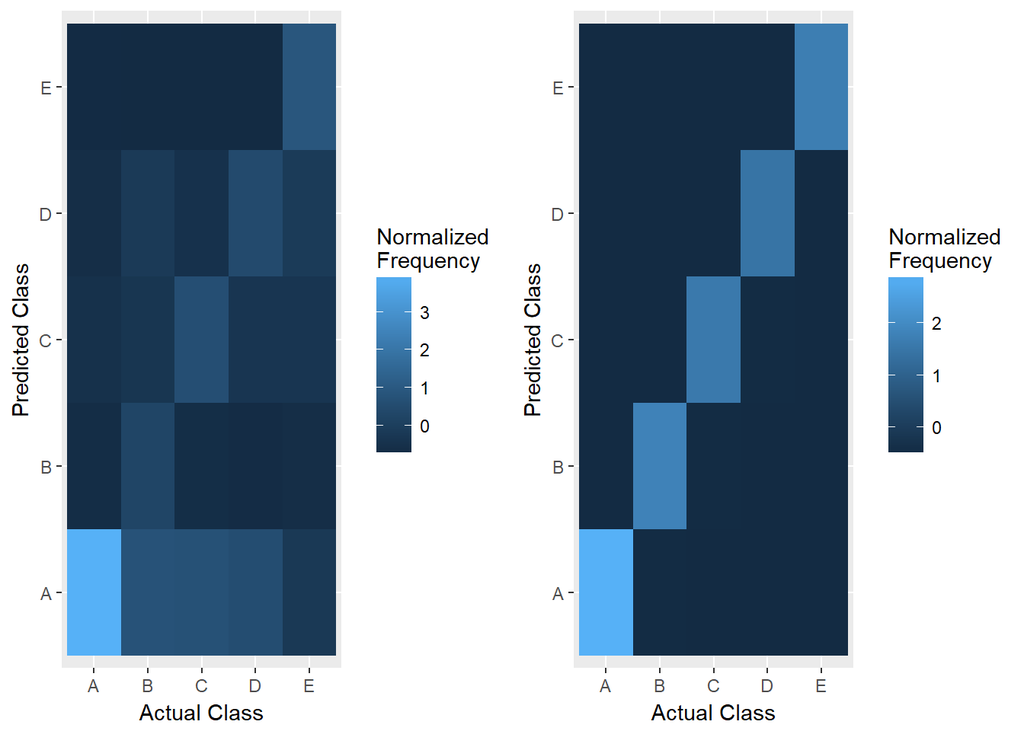

```r
par(mfrow = c(2,1))
 df <- normalize(as.data.frame(dt.conf$table))
        plot1 <- ggplot(df)
        plot1 <- plot1 + geom_tile(aes(x=Prediction, y=Reference, fill=Freq)) +
                scale_x_discrete(name="Actual Class") +
                scale_y_discrete(name="Predicted Class") +
            ##    scale_fill_gradient(breaks=seq(from=-.3, to=3, by=.2)) +
                labs(fill="Normalized\nFrequency")

 df <- normalize(as.data.frame(rf.conf$table))
        plot2 <- ggplot(df)
        plot2<- plot2 + geom_tile(aes(x=Prediction, y=Reference, fill=Freq)) +
                scale_x_discrete(name="Actual Class") +
                scale_y_discrete(name="Predicted Class") +
            ##    scale_fill_gradient(breaks=seq(from=-.3, to=3, by=.2)) +
                labs(fill="Normalized\nFrequency")
grid.arrange(plot1, plot2, nrow = 1)
```

## References

Ugulino, W.; Cardador, D.; Vega, K.; Velloso, E.; Milidiu, R.; Fuks, H. Wearable Computing: Accelerometers’ Data Classification of Body Postures and Movements. Proceedings of 21st Brazilian Symposium on Artificial Intelligence. Advances in Artificial Intelligence - SBIA 2012. In: Lecture Notes in Computer Science. , pp. 52-61. Curitiba, PR: Springer Berlin / Heidelberg, 2012. ISBN 978-3-642-34458-9. DOI: 10.1007/978-3-642-34459-6_6. Cited by 2 (Google Scholar)